# bank_marketing

```python
import pandas as pd
import seaborn as sn
import matplotlib.pyplot as plt
%matplotlib inline
```

```python
df = pd.read_csv('bank/bank2trab.csv')
```

```python
len(df)
```

```
2283
```

```python
len(df[(df.y=='no')])
```

```
1762
```

```python
df.drop_duplicates(inplace=True)
```

```python
df
```

|  | age | job | marital | education | default | balance | housing | loan | contact | day | month | duration | campaign | pdays | previous | poutcome | y |
| --- | --- | --- | --- | --- | --- | --- | --- | --- | --- | --- | --- | --- | --- | --- | --- | --- | --- |
| 0 | 57 | self-employed | married | secondary | no | 11494 | no | no | cellular | 19 | nov | 198 | 1 | -1 | 0 | unknown | no |
| 1 | 31 | blue-collar | married | primary | no | 620 | no | no | cellular | 30 | mar | 95 | 1 | -1 | 0 | unknown | no |
| 2 | 31 | management | married | tertiary | no | 8312 | no | no | cellular | 29 | aug | 43 | 13 | -1 | 0 | unknown | no |
| 3 | 47 | blue-collar | divorced | primary | no | 126 | yes | no | unknown | 3 | jun | 2456 | 2 | -1 | 0 | unknown | yes |
| 4 | 34 | housemaid | married | secondary | no | 0 | yes | no | unknown | 30 | oct | 154 | 1 | -1 | 0 | unknown | yes |
| 5 | 57 | blue-collar | married | primary | no | 452 | yes | no | unknown | 13 | may | 139 | 4 | -1 | 0 | unknown | no |
| 6 | 34 | admin. | married | tertiary | no | 2552 | yes | yes | cellular | 25 | sep | 74 | 1 | -1 | 0 | unknown | no |
| 7 | 41 | blue-collar | married | secondary | no | 780 | yes | no | cellular | 15 | may | 432 | 3 | -1 | 0 | unknown | no |
| 8 | 40 | management | married | tertiary | no | 8969 | yes | no | cellular | 17 | nov | 153 | 1 | -1 | 0 | unknown | no |
| 9 | 26 | student | single | secondary | no | 279 | no | no | cellular | 7 | may | 239 | 3 | -1 | 0 | unknown | no |
| 10 | 30 | admin. | married | secondary | no | 518 | yes | no | cellular | 8 | may | 127 | 1 | -1 | 0 | unknown | no |
| 11 | 52 | management | married | tertiary | no | 1339 | yes | no | cellular | 22 | aug | 343 | 5 | -1 | 0 | unknown | no |
| 12 | 45 | blue-collar | single | secondary | no | 0 | yes | no | cellular | 26 | apr | 1472 | 1 | 192 | 4 | failure | yes |
| 13 | 36 | unemployed | married | secondary | no | -129 | yes | no | cellular | 29 | jul | 121 | 3 | -1 | 0 | unknown | no |
| 14 | 25 | management | single | tertiary | no | 808 | no | no | cellular | 18 | sep | 267 | 2 | 114 | 2 | failure | yes |
| 15 | 31 | blue-collar | single | secondary | no | 16 | no | no | cellular | 7 | jul | 387 | 1 | -1 | 0 | unknown | no |
| 16 | 27 | management | single | tertiary | no | 446 | no | no | cellular | 23 | jun | 205 | 3 | -1 | 0 | unknown | no |
| 17 | 33 | blue-collar | married | secondary | no | 889 | yes | no | unknown | 18 | sep | 13 | 1 | 373 | 6 | success | no |
| 18 | 22 | student | single | secondary | no | 2488 | no | no | cellular | 8 | nov | 449 | 2 | 38 | 10 | other | yes |
| 19 | 41 | blue-collar | single | secondary | yes | -386 | no | yes | cellular | 20 | nov | 477 | 1 | -1 | 0 | unknown | yes |
| 20 | 38 | admin. | single | secondary | no | -23 | no | no | cellular | 20 | nov | 48 | 2 | -1 | 0 | unknown | no |
| 21 | 63 | retired | divorced | secondary | no | 1490 | no | no | cellular | 8 | jun | 506 | 1 | -1 | 0 | unknown | yes |
| 22 | 50 | admin. | divorced | secondary | no | 202 | no | yes | cellular | 17 | nov | 148 | 1 | -1 | 0 | unknown | no |
| 23 | 41 | technician | married | secondary | no | 288 | yes | no | unknown | 15 | may | 221 | 4 | -1 | 0 | unknown | no |
| 24 | 49 | unemployed | married | secondary | no | 769 | yes | no | unknown | 14 | may | 257 | 1 | -1 | 0 | unknown | no |
| 25 | 36 | management | married | tertiary | no | 9 | no | no | cellular | 11 | aug | 386 | 4 | -1 | 0 | unknown | yes |
| 26 | 58 | blue-collar | divorced | secondary | no | 543 | no | yes | telephone | 17 | jul | 264 | 3 | -1 | 0 | unknown | no |
| 27 | 58 | technician | single | secondary | no | 409 | no | yes | cellular | 14 | jul | 643 | 2 | -1 | 0 | unknown | no |
| 28 | 47 | management | single | tertiary | no | 153 | yes | no | cellular | 18 | nov | 192 | 2 | -1 | 0 | unknown | no |
| 29 | 46 | admin. | divorced | secondary | no | 2232 | no | no | cellular | 13 | feb | 121 | 1 | -1 | 0 | unknown | yes |
| ... | ... | ... | ... | ... | ... | ... | ... | ... | ... | ... | ... | ... | ... | ... | ... | ... | ... |
| 2253 | 32 | management | single | tertiary | no | 151 | yes | no | unknown | 6 | may | 118 | 1 | -1 | 0 | unknown | no |
| 2254 | 51 | management | single | tertiary | yes | -55 | yes | no | cellular | 11 | may | 281 | 2 | 266 | 6 | failure | no |
| 2255 | 44 | entrepreneur | married | primary | no | 276 | yes | yes | unknown | 15 | may | 219 | 1 | -1 | 0 | unknown | no |
| 2256 | 26 | technician | married | tertiary | no | 3825 | yes | no | unknown | 13 | may | 107 | 1 | -1 | 0 | unknown | no |
| 2257 | 52 | services | married | secondary | no | 657 | no | no | telephone | 7 | jul | 398 | 2 | 460 | 2 | failure | yes |
| 2258 | 26 | blue-collar | single | secondary | no | -32 | yes | yes | cellular | 31 | jul | 14 | 6 | -1 | 0 | unknown | no |
| 2259 | 37 | entrepreneur | married | tertiary | no | 2685 | no | no | unknown | 20 | jun | 187 | 2 | -1 | 0 | unknown | no |
| 2260 | 43 | blue-collar | married | primary | no | 757 | yes | no | unknown | 9 | may | 315 | 4 | -1 | 0 | unknown | no |
| 2261 | 33 | self-employed | single | tertiary | no | 2155 | no | no | cellular | 17 | nov | 295 | 1 | -1 | 0 | unknown | no |
| 2262 | 48 | admin. | divorced | secondary | no | 4099 | no | no | cellular | 2 | apr | 397 | 2 | -1 | 0 | unknown | yes |
| 2263 | 32 | technician | single | secondary | no | 0 | no | no | cellular | 18 | aug | 594 | 4 | -1 | 0 | unknown | yes |
| 2264 | 38 | technician | married | secondary | no | 226 | yes | no | unknown | 30 | may | 762 | 3 | -1 | 0 | unknown | yes |
| 2265 | 52 | blue-collar | married | primary | no | 1054 | no | no | cellular | 4 | aug | 273 | 1 | -1 | 0 | unknown | no |
| 2266 | 32 | blue-collar | married | primary | no | 103 | no | no | cellular | 23 | jul | 312 | 1 | -1 | 0 | unknown | no |
| 2267 | 39 | services | divorced | secondary | no | 687 | yes | no | cellular | 9 | jul | 869 | 1 | -1 | 0 | unknown | yes |
| 2268 | 20 | student | single | secondary | no | 1191 | no | no | cellular | 12 | feb | 274 | 1 | -1 | 0 | unknown | no |
| 2269 | 52 | retired | divorced | primary | no | 353 | no | no | cellular | 31 | jul | 395 | 4 | -1 | 0 | unknown | no |
| 2270 | 31 | management | married | tertiary | no | 13 | no | no | cellular | 28 | aug | 110 | 5 | -1 | 0 | unknown | no |
| 2271 | 33 | technician | divorced | secondary | no | 9 | no | no | cellular | 21 | aug | 91 | 2 | -1 | 0 | unknown | no |
| 2272 | 32 | management | married | secondary | no | 350 | yes | no | unknown | 28 | may | 110 | 2 | -1 | 0 | unknown | no |
| 2273 | 56 | admin. | married | unknown | no | 2038 | no | no | cellular | 8 | feb | 405 | 1 | 305 | 1 | success | no |
| 2274 | 38 | admin. | married | tertiary | no | 605 | no | no | cellular | 18 | nov | 147 | 2 | -1 | 0 | unknown | no |
| 2275 | 47 | blue-collar | married | secondary | no | 1230 | yes | no | cellular | 30 | apr | 412 | 1 | 169 | 1 | success | yes |
| 2276 | 43 | management | married | secondary | no | 17555 | no | no | cellular | 26 | aug | 14 | 14 | -1 | 0 | unknown | no |
| 2277 | 40 | management | married | secondary | no | 643 | yes | no | cellular | 17 | apr | 74 | 2 | 256 | 1 | failure | no |
| 2278 | 33 | services | single | secondary | no | -56 | no | yes | cellular | 10 | jul | 119 | 5 | -1 | 0 | unknown | no |
| 2279 | 53 | technician | divorced | secondary | no | 320 | no | no | cellular | 9 | jul | 175 | 1 | -1 | 0 | unknown | no |
| 2280 | 31 | blue-collar | married | secondary | no | 1243 | yes | no | unknown | 21 | may | 32 | 1 | -1 | 0 | unknown | no |
| 2281 | 29 | admin. | single | secondary | no | 428 | yes | yes | cellular | 7 | may | 54 | 1 | 345 | 2 | failure | no |
| 2282 | 28 | admin. | single | secondary | no | 26 | yes | no | cellular | 7 | may | 227 | 2 | -1 | 0 | unknown | no |

2283 rows × 17 columns

## 1ªQuestão

### a)

#### Nome: Bank Marketing Descrição: Os dados estão relacionados com campanhas de marketing direto (chamadas telefônicas) de uma instituição bancária portuguesa. Volume de dados: Bank.csv – 4521 registros

### b)

##### age: idade do cliente job: tipo de trabalho do cliente marital: situação conjugal do cliente education: formação educacional do cliente default: o crédito é padrão ou não? balance: saldo anual médio, em euros (numérico) housing: tem empréstimo habitacional? loan: tem empréstimo pessoal? relacionado com o último contato da campanha atual contact: contato para comunicação day: último dia de contato do mês (numérico) month: último contato mês do ano duration: duração do último contato, em segundos outros atributos campaign: número de contatos realizados durante esta campanha para este cliente pdays: número de dias que passou após o último contato do cliente de uma campanha anterior (numérico, -1 significa que o cliente não foi contatado anteriormente) previous: número de contatos realizados antes desta campanha e para este cliente poutcome: resultado da campanha de marketing anterior("desconhecido", "outro", "falha", "sucesso") y: o cliente subscreveu um depósito a prazo?

### C)

#### O objetivo da classificação é prever se o cliente irá subscrever um depósito de prazo (variável y).

## 2ª Questão

### a)

#### tipos das colunas:

#### numéricos = age,balance,day,duration,campaign,pdays,previous

#### categórico = job,marital,education,contact,month,poutcome

#### binário = default, housing, loan,y

### b)

```python
for field in df.columns:
    print(field,'NaN:',df[field].isnull().sum())
```

```
age NaN: 0
job NaN: 0
marital NaN: 0
education NaN: 0
default NaN: 0
balance NaN: 0
housing NaN: 0
loan NaN: 0
contact NaN: 0
day NaN: 0
month NaN: 0
duration NaN: 0
campaign NaN: 0
pdays NaN: 0
previous NaN: 0
poutcome NaN: 0
y NaN: 0
```

#### não existem campos nulos no dataset

### C)

#### variáveis categóricas: job, marital , education, contact, month,poutcome

```python
a=df[df.job=='unknown']
```

```python
len(a)
```

```
20
```

#### removendo as linhas cujos valores sejam desconhecidos para tipo de trabalho

```python
df.drop(df[df.job=='unknown'].index,inplace=True)
```

```python
len(df[(df.education=='unknown')])
```

```
91
```

#### removendo as linhas cujos valores sejam desconhecidos para educação

```python
df.drop(df[df.education=='unknown'].index,inplace=True)
```

#### criando uma coluna se trabalha ou estuda chamada t_e, pois acho que apenas com essas duas respostas resumiremos toda a coluna job.

```python
def t_e(s):
    if s=='student':
        return 1
    else:
        return 2
```

```python
df['t_e']=df['job'].apply(t_e)
```

#### criando uma coluna class_saldo baseado em balance onde agruparemos em classes os clientes de acordo com o valor do seu saldo

```python
def saldo(s):

    if s<0:
        return 0
    elif s==0:
        return 1
    elif s>0 and s<501:
        return 2

    elif s>500 and s<1001:
        return 3
    elif s>1000 and s<1501:
        return 4
    elif s>1500 and s<2001:
        return 5
    elif s>2000 and s<2501:
        return 6
    elif s>2500 and s<3001:
        return 7
    elif s>3000 and s<3501:
        return 8
    elif s>3500 and s<4001:
        return 9
    elif s>4000:
        return 10
```

```python
df['class_saldo']=df['balance'].apply(saldo)
```

#### criando uma coluna emprestimo com os valores 0,1,2 de acordo com a quantidade de empréstimos para resumir em uma coluna as duas colunas housing e loan, pois as duas colunas são similares na questão do cliente ter algum tipo de empréstimo

```python
df['emprestimo']=0
```

```python
df.loc[(df['housing']=='yes') | (df['loan']=='yes'),'emprestimo']=1
```

```python
df.loc[(df['housing']=='yes') & (df['loan']=='yes'),'emprestimo']=2
```

```python
df
```

|  | age | job | marital | education | default | balance | housing | loan | contact | day | month | duration | campaign | pdays | previous | poutcome | y | t_e | class_saldo | emprestimo |
| --- | --- | --- | --- | --- | --- | --- | --- | --- | --- | --- | --- | --- | --- | --- | --- | --- | --- | --- | --- | --- |
| 0 | 57 | self-employed | married | secondary | no | 11494 | no | no | cellular | 19 | nov | 198 | 1 | -1 | 0 | unknown | no | 2 | 10 | 0 |
| 1 | 31 | blue-collar | married | primary | no | 620 | no | no | cellular | 30 | mar | 95 | 1 | -1 | 0 | unknown | no | 2 | 3 | 0 |
| 2 | 31 | management | married | tertiary | no | 8312 | no | no | cellular | 29 | aug | 43 | 13 | -1 | 0 | unknown | no | 2 | 10 | 0 |
| 3 | 47 | blue-collar | divorced | primary | no | 126 | yes | no | unknown | 3 | jun | 2456 | 2 | -1 | 0 | unknown | yes | 2 | 2 | 1 |
| 4 | 34 | housemaid | married | secondary | no | 0 | yes | no | unknown | 30 | oct | 154 | 1 | -1 | 0 | unknown | yes | 2 | 1 | 1 |
| 5 | 57 | blue-collar | married | primary | no | 452 | yes | no | unknown | 13 | may | 139 | 4 | -1 | 0 | unknown | no | 2 | 2 | 1 |
| 6 | 34 | admin. | married | tertiary | no | 2552 | yes | yes | cellular | 25 | sep | 74 | 1 | -1 | 0 | unknown | no | 2 | 7 | 2 |
| 7 | 41 | blue-collar | married | secondary | no | 780 | yes | no | cellular | 15 | may | 432 | 3 | -1 | 0 | unknown | no | 2 | 3 | 1 |
| 8 | 40 | management | married | tertiary | no | 8969 | yes | no | cellular | 17 | nov | 153 | 1 | -1 | 0 | unknown | no | 2 | 10 | 1 |
| 9 | 26 | student | single | secondary | no | 279 | no | no | cellular | 7 | may | 239 | 3 | -1 | 0 | unknown | no | 1 | 2 | 0 |
| 10 | 30 | admin. | married | secondary | no | 518 | yes | no | cellular | 8 | may | 127 | 1 | -1 | 0 | unknown | no | 2 | 3 | 1 |
| 11 | 52 | management | married | tertiary | no | 1339 | yes | no | cellular | 22 | aug | 343 | 5 | -1 | 0 | unknown | no | 2 | 4 | 1 |
| 12 | 45 | blue-collar | single | secondary | no | 0 | yes | no | cellular | 26 | apr | 1472 | 1 | 192 | 4 | failure | yes | 2 | 1 | 1 |
| 13 | 36 | unemployed | married | secondary | no | -129 | yes | no | cellular | 29 | jul | 121 | 3 | -1 | 0 | unknown | no | 2 | 0 | 1 |
| 14 | 25 | management | single | tertiary | no | 808 | no | no | cellular | 18 | sep | 267 | 2 | 114 | 2 | failure | yes | 2 | 3 | 0 |
| 15 | 31 | blue-collar | single | secondary | no | 16 | no | no | cellular | 7 | jul | 387 | 1 | -1 | 0 | unknown | no | 2 | 2 | 0 |
| 16 | 27 | management | single | tertiary | no | 446 | no | no | cellular | 23 | jun | 205 | 3 | -1 | 0 | unknown | no | 2 | 2 | 0 |
| 17 | 33 | blue-collar | married | secondary | no | 889 | yes | no | unknown | 18 | sep | 13 | 1 | 373 | 6 | success | no | 2 | 3 | 1 |
| 18 | 22 | student | single | secondary | no | 2488 | no | no | cellular | 8 | nov | 449 | 2 | 38 | 10 | other | yes | 1 | 6 | 0 |
| 19 | 41 | blue-collar | single | secondary | yes | -386 | no | yes | cellular | 20 | nov | 477 | 1 | -1 | 0 | unknown | yes | 2 | 0 | 1 |
| 20 | 38 | admin. | single | secondary | no | -23 | no | no | cellular | 20 | nov | 48 | 2 | -1 | 0 | unknown | no | 2 | 0 | 0 |
| 21 | 63 | retired | divorced | secondary | no | 1490 | no | no | cellular | 8 | jun | 506 | 1 | -1 | 0 | unknown | yes | 2 | 4 | 0 |
| 22 | 50 | admin. | divorced | secondary | no | 202 | no | yes | cellular | 17 | nov | 148 | 1 | -1 | 0 | unknown | no | 2 | 2 | 1 |
| 23 | 41 | technician | married | secondary | no | 288 | yes | no | unknown | 15 | may | 221 | 4 | -1 | 0 | unknown | no | 2 | 2 | 1 |
| 24 | 49 | unemployed | married | secondary | no | 769 | yes | no | unknown | 14 | may | 257 | 1 | -1 | 0 | unknown | no | 2 | 3 | 1 |
| 25 | 36 | management | married | tertiary | no | 9 | no | no | cellular | 11 | aug | 386 | 4 | -1 | 0 | unknown | yes | 2 | 2 | 0 |
| 26 | 58 | blue-collar | divorced | secondary | no | 543 | no | yes | telephone | 17 | jul | 264 | 3 | -1 | 0 | unknown | no | 2 | 3 | 1 |
| 27 | 58 | technician | single | secondary | no | 409 | no | yes | cellular | 14 | jul | 643 | 2 | -1 | 0 | unknown | no | 2 | 2 | 1 |
| 28 | 47 | management | single | tertiary | no | 153 | yes | no | cellular | 18 | nov | 192 | 2 | -1 | 0 | unknown | no | 2 | 2 | 1 |
| 29 | 46 | admin. | divorced | secondary | no | 2232 | no | no | cellular | 13 | feb | 121 | 1 | -1 | 0 | unknown | yes | 2 | 6 | 0 |
| ... | ... | ... | ... | ... | ... | ... | ... | ... | ... | ... | ... | ... | ... | ... | ... | ... | ... | ... | ... | ... |
| 2252 | 41 | blue-collar | married | primary | no | 849 | yes | no | unknown | 15 | may | 72 | 1 | -1 | 0 | unknown | no | 2 | 3 | 1 |
| 2253 | 32 | management | single | tertiary | no | 151 | yes | no | unknown | 6 | may | 118 | 1 | -1 | 0 | unknown | no | 2 | 2 | 1 |
| 2254 | 51 | management | single | tertiary | yes | -55 | yes | no | cellular | 11 | may | 281 | 2 | 266 | 6 | failure | no | 2 | 0 | 1 |
| 2255 | 44 | entrepreneur | married | primary | no | 276 | yes | yes | unknown | 15 | may | 219 | 1 | -1 | 0 | unknown | no | 2 | 2 | 2 |
| 2256 | 26 | technician | married | tertiary | no | 3825 | yes | no | unknown | 13 | may | 107 | 1 | -1 | 0 | unknown | no | 2 | 9 | 1 |
| 2257 | 52 | services | married | secondary | no | 657 | no | no | telephone | 7 | jul | 398 | 2 | 460 | 2 | failure | yes | 2 | 3 | 0 |
| 2258 | 26 | blue-collar | single | secondary | no | -32 | yes | yes | cellular | 31 | jul | 14 | 6 | -1 | 0 | unknown | no | 2 | 0 | 2 |
| 2259 | 37 | entrepreneur | married | tertiary | no | 2685 | no | no | unknown | 20 | jun | 187 | 2 | -1 | 0 | unknown | no | 2 | 7 | 0 |
| 2260 | 43 | blue-collar | married | primary | no | 757 | yes | no | unknown | 9 | may | 315 | 4 | -1 | 0 | unknown | no | 2 | 3 | 1 |
| 2261 | 33 | self-employed | single | tertiary | no | 2155 | no | no | cellular | 17 | nov | 295 | 1 | -1 | 0 | unknown | no | 2 | 6 | 0 |
| 2262 | 48 | admin. | divorced | secondary | no | 4099 | no | no | cellular | 2 | apr | 397 | 2 | -1 | 0 | unknown | yes | 2 | 10 | 0 |
| 2263 | 32 | technician | single | secondary | no | 0 | no | no | cellular | 18 | aug | 594 | 4 | -1 | 0 | unknown | yes | 2 | 1 | 0 |
| 2264 | 38 | technician | married | secondary | no | 226 | yes | no | unknown | 30 | may | 762 | 3 | -1 | 0 | unknown | yes | 2 | 2 | 1 |
| 2265 | 52 | blue-collar | married | primary | no | 1054 | no | no | cellular | 4 | aug | 273 | 1 | -1 | 0 | unknown | no | 2 | 4 | 0 |
| 2266 | 32 | blue-collar | married | primary | no | 103 | no | no | cellular | 23 | jul | 312 | 1 | -1 | 0 | unknown | no | 2 | 2 | 0 |
| 2267 | 39 | services | divorced | secondary | no | 687 | yes | no | cellular | 9 | jul | 869 | 1 | -1 | 0 | unknown | yes | 2 | 3 | 1 |
| 2268 | 20 | student | single | secondary | no | 1191 | no | no | cellular | 12 | feb | 274 | 1 | -1 | 0 | unknown | no | 1 | 4 | 0 |
| 2269 | 52 | retired | divorced | primary | no | 353 | no | no | cellular | 31 | jul | 395 | 4 | -1 | 0 | unknown | no | 2 | 2 | 0 |
| 2270 | 31 | management | married | tertiary | no | 13 | no | no | cellular | 28 | aug | 110 | 5 | -1 | 0 | unknown | no | 2 | 2 | 0 |
| 2271 | 33 | technician | divorced | secondary | no | 9 | no | no | cellular | 21 | aug | 91 | 2 | -1 | 0 | unknown | no | 2 | 2 | 0 |
| 2272 | 32 | management | married | secondary | no | 350 | yes | no | unknown | 28 | may | 110 | 2 | -1 | 0 | unknown | no | 2 | 2 | 1 |
| 2274 | 38 | admin. | married | tertiary | no | 605 | no | no | cellular | 18 | nov | 147 | 2 | -1 | 0 | unknown | no | 2 | 3 | 0 |
| 2275 | 47 | blue-collar | married | secondary | no | 1230 | yes | no | cellular | 30 | apr | 412 | 1 | 169 | 1 | success | yes | 2 | 4 | 1 |
| 2276 | 43 | management | married | secondary | no | 17555 | no | no | cellular | 26 | aug | 14 | 14 | -1 | 0 | unknown | no | 2 | 10 | 0 |
| 2277 | 40 | management | married | secondary | no | 643 | yes | no | cellular | 17 | apr | 74 | 2 | 256 | 1 | failure | no | 2 | 3 | 1 |
| 2278 | 33 | services | single | secondary | no | -56 | no | yes | cellular | 10 | jul | 119 | 5 | -1 | 0 | unknown | no | 2 | 0 | 1 |
| 2279 | 53 | technician | divorced | secondary | no | 320 | no | no | cellular | 9 | jul | 175 | 1 | -1 | 0 | unknown | no | 2 | 2 | 0 |
| 2280 | 31 | blue-collar | married | secondary | no | 1243 | yes | no | unknown | 21 | may | 32 | 1 | -1 | 0 | unknown | no | 2 | 4 | 1 |
| 2281 | 29 | admin. | single | secondary | no | 428 | yes | yes | cellular | 7 | may | 54 | 1 | 345 | 2 | failure | no | 2 | 2 | 2 |
| 2282 | 28 | admin. | single | secondary | no | 26 | yes | no | cellular | 7 | may | 227 | 2 | -1 | 0 | unknown | no | 2 | 2 | 1 |

2172 rows × 20 columns

#### criação da coluna clas_temp_lig, de acordo com a duração das ligações dos clientes na campanha

```python
def clas_temp_lig(s):
    return int(s/60)
```

```python
df['clas_temp_lig']=df['duration'].apply(clas_temp_lig)
```

#### criação da coluna se já foi contactado em campanhas anteriores ou não

```python
def cont_antes(s):
    if s==-1:
        return 0
    else:
        return 1
```

```python
df['cont_antes']=df['pdays'].apply(cont_antes)
```

### d)

```python
len(df[(df.poutcome=='unknown')])
```

```
1720
```

```python
df.drop('default',axis=1,inplace=True)
```

```python
df.drop('previous',axis=1,inplace=True)
```

```python
df.drop('job',axis=1,inplace=True)
```

```python
df.drop('age',axis=1,inplace=True)
```

```python
df.drop('marital',axis=1,inplace=True)
```

```python
df.drop('contact',axis=1,inplace=True)
```

```python
df.drop('housing',axis=1,inplace=True)
```

```python
df.drop('loan',axis=1,inplace=True)
```

```python
df.drop('day',axis=1,inplace=True)
```

```python
df.drop('pdays',axis=1,inplace=True)
```

```python
df.drop('month',axis=1,inplace=True)
```

```python
df.drop('poutcome',axis=1,inplace=True)
```

```python
df.drop('duration',axis=1,inplace=True)
```

```python
df.drop('balance',axis=1,inplace=True)
```

```python
len(df)
```

```
2172
```

### f)

```python
df['education'] = df['education'].map( {'primary':1,
                                       'secondary':2,
                                       'tertiary':3}).astype(int)
```

```python
len(df)
```

```
2172
```

```python
df
```

|  | education | campaign | y | t_e | class_saldo | emprestimo | clas_temp_lig | cont_antes |
| --- | --- | --- | --- | --- | --- | --- | --- | --- |
| 0 | 2 | 1 | no | 2 | 10 | 0 | 3 | 0 |
| 1 | 1 | 1 | no | 2 | 3 | 0 | 1 | 0 |
| 2 | 3 | 13 | no | 2 | 10 | 0 | 0 | 0 |
| 3 | 1 | 2 | yes | 2 | 2 | 1 | 40 | 0 |
| 4 | 2 | 1 | yes | 2 | 1 | 1 | 2 | 0 |
| 5 | 1 | 4 | no | 2 | 2 | 1 | 2 | 0 |
| 6 | 3 | 1 | no | 2 | 7 | 2 | 1 | 0 |
| 7 | 2 | 3 | no | 2 | 3 | 1 | 7 | 0 |
| 8 | 3 | 1 | no | 2 | 10 | 1 | 2 | 0 |
| 9 | 2 | 3 | no | 1 | 2 | 0 | 3 | 0 |
| 10 | 2 | 1 | no | 2 | 3 | 1 | 2 | 0 |
| 11 | 3 | 5 | no | 2 | 4 | 1 | 5 | 0 |
| 12 | 2 | 1 | yes | 2 | 1 | 1 | 24 | 1 |
| 13 | 2 | 3 | no | 2 | 0 | 1 | 2 | 0 |
| 14 | 3 | 2 | yes | 2 | 3 | 0 | 4 | 1 |
| 15 | 2 | 1 | no | 2 | 2 | 0 | 6 | 0 |
| 16 | 3 | 3 | no | 2 | 2 | 0 | 3 | 0 |
| 17 | 2 | 1 | no | 2 | 3 | 1 | 0 | 1 |
| 18 | 2 | 2 | yes | 1 | 6 | 0 | 7 | 1 |
| 19 | 2 | 1 | yes | 2 | 0 | 1 | 7 | 0 |
| 20 | 2 | 2 | no | 2 | 0 | 0 | 0 | 0 |
| 21 | 2 | 1 | yes | 2 | 4 | 0 | 8 | 0 |
| 22 | 2 | 1 | no | 2 | 2 | 1 | 2 | 0 |
| 23 | 2 | 4 | no | 2 | 2 | 1 | 3 | 0 |
| 24 | 2 | 1 | no | 2 | 3 | 1 | 4 | 0 |
| 25 | 3 | 4 | yes | 2 | 2 | 0 | 6 | 0 |
| 26 | 2 | 3 | no | 2 | 3 | 1 | 4 | 0 |
| 27 | 2 | 2 | no | 2 | 2 | 1 | 10 | 0 |
| 28 | 3 | 2 | no | 2 | 2 | 1 | 3 | 0 |
| 29 | 2 | 1 | yes | 2 | 6 | 0 | 2 | 0 |
| ... | ... | ... | ... | ... | ... | ... | ... | ... |
| 2252 | 1 | 1 | no | 2 | 3 | 1 | 1 | 0 |
| 2253 | 3 | 1 | no | 2 | 2 | 1 | 1 | 0 |
| 2254 | 3 | 2 | no | 2 | 0 | 1 | 4 | 1 |
| 2255 | 1 | 1 | no | 2 | 2 | 2 | 3 | 0 |
| 2256 | 3 | 1 | no | 2 | 9 | 1 | 1 | 0 |
| 2257 | 2 | 2 | yes | 2 | 3 | 0 | 6 | 1 |
| 2258 | 2 | 6 | no | 2 | 0 | 2 | 0 | 0 |
| 2259 | 3 | 2 | no | 2 | 7 | 0 | 3 | 0 |
| 2260 | 1 | 4 | no | 2 | 3 | 1 | 5 | 0 |
| 2261 | 3 | 1 | no | 2 | 6 | 0 | 4 | 0 |
| 2262 | 2 | 2 | yes | 2 | 10 | 0 | 6 | 0 |
| 2263 | 2 | 4 | yes | 2 | 1 | 0 | 9 | 0 |
| 2264 | 2 | 3 | yes | 2 | 2 | 1 | 12 | 0 |
| 2265 | 1 | 1 | no | 2 | 4 | 0 | 4 | 0 |
| 2266 | 1 | 1 | no | 2 | 2 | 0 | 5 | 0 |
| 2267 | 2 | 1 | yes | 2 | 3 | 1 | 14 | 0 |
| 2268 | 2 | 1 | no | 1 | 4 | 0 | 4 | 0 |
| 2269 | 1 | 4 | no | 2 | 2 | 0 | 6 | 0 |
| 2270 | 3 | 5 | no | 2 | 2 | 0 | 1 | 0 |
| 2271 | 2 | 2 | no | 2 | 2 | 0 | 1 | 0 |
| 2272 | 2 | 2 | no | 2 | 2 | 1 | 1 | 0 |
| 2274 | 3 | 2 | no | 2 | 3 | 0 | 2 | 0 |
| 2275 | 2 | 1 | yes | 2 | 4 | 1 | 6 | 1 |
| 2276 | 2 | 14 | no | 2 | 10 | 0 | 0 | 0 |
| 2277 | 2 | 2 | no | 2 | 3 | 1 | 1 | 1 |
| 2278 | 2 | 5 | no | 2 | 0 | 1 | 1 | 0 |
| 2279 | 2 | 1 | no | 2 | 2 | 0 | 2 | 0 |
| 2280 | 2 | 1 | no | 2 | 4 | 1 | 0 | 0 |
| 2281 | 2 | 1 | no | 2 | 2 | 2 | 0 | 1 |
| 2282 | 2 | 2 | no | 2 | 2 | 1 | 3 | 0 |

2172 rows × 8 columns

```python
df['y'] = df['y'].map( {'no' : 0 ,'yes':1}).astype(int)
```

```python
df
```

|  | education | campaign | y | t_e | class_saldo | emprestimo | clas_temp_lig | cont_antes |
| --- | --- | --- | --- | --- | --- | --- | --- | --- |
| 0 | 2 | 1 | 0 | 2 | 10 | 0 | 3 | 0 |
| 1 | 1 | 1 | 0 | 2 | 3 | 0 | 1 | 0 |
| 2 | 3 | 13 | 0 | 2 | 10 | 0 | 0 | 0 |
| 3 | 1 | 2 | 1 | 2 | 2 | 1 | 40 | 0 |
| 4 | 2 | 1 | 1 | 2 | 1 | 1 | 2 | 0 |
| 5 | 1 | 4 | 0 | 2 | 2 | 1 | 2 | 0 |
| 6 | 3 | 1 | 0 | 2 | 7 | 2 | 1 | 0 |
| 7 | 2 | 3 | 0 | 2 | 3 | 1 | 7 | 0 |
| 8 | 3 | 1 | 0 | 2 | 10 | 1 | 2 | 0 |
| 9 | 2 | 3 | 0 | 1 | 2 | 0 | 3 | 0 |
| 10 | 2 | 1 | 0 | 2 | 3 | 1 | 2 | 0 |
| 11 | 3 | 5 | 0 | 2 | 4 | 1 | 5 | 0 |
| 12 | 2 | 1 | 1 | 2 | 1 | 1 | 24 | 1 |
| 13 | 2 | 3 | 0 | 2 | 0 | 1 | 2 | 0 |
| 14 | 3 | 2 | 1 | 2 | 3 | 0 | 4 | 1 |
| 15 | 2 | 1 | 0 | 2 | 2 | 0 | 6 | 0 |
| 16 | 3 | 3 | 0 | 2 | 2 | 0 | 3 | 0 |
| 17 | 2 | 1 | 0 | 2 | 3 | 1 | 0 | 1 |
| 18 | 2 | 2 | 1 | 1 | 6 | 0 | 7 | 1 |
| 19 | 2 | 1 | 1 | 2 | 0 | 1 | 7 | 0 |
| 20 | 2 | 2 | 0 | 2 | 0 | 0 | 0 | 0 |
| 21 | 2 | 1 | 1 | 2 | 4 | 0 | 8 | 0 |
| 22 | 2 | 1 | 0 | 2 | 2 | 1 | 2 | 0 |
| 23 | 2 | 4 | 0 | 2 | 2 | 1 | 3 | 0 |
| 24 | 2 | 1 | 0 | 2 | 3 | 1 | 4 | 0 |
| 25 | 3 | 4 | 1 | 2 | 2 | 0 | 6 | 0 |
| 26 | 2 | 3 | 0 | 2 | 3 | 1 | 4 | 0 |
| 27 | 2 | 2 | 0 | 2 | 2 | 1 | 10 | 0 |
| 28 | 3 | 2 | 0 | 2 | 2 | 1 | 3 | 0 |
| 29 | 2 | 1 | 1 | 2 | 6 | 0 | 2 | 0 |
| ... | ... | ... | ... | ... | ... | ... | ... | ... |
| 2252 | 1 | 1 | 0 | 2 | 3 | 1 | 1 | 0 |
| 2253 | 3 | 1 | 0 | 2 | 2 | 1 | 1 | 0 |
| 2254 | 3 | 2 | 0 | 2 | 0 | 1 | 4 | 1 |
| 2255 | 1 | 1 | 0 | 2 | 2 | 2 | 3 | 0 |
| 2256 | 3 | 1 | 0 | 2 | 9 | 1 | 1 | 0 |
| 2257 | 2 | 2 | 1 | 2 | 3 | 0 | 6 | 1 |
| 2258 | 2 | 6 | 0 | 2 | 0 | 2 | 0 | 0 |
| 2259 | 3 | 2 | 0 | 2 | 7 | 0 | 3 | 0 |
| 2260 | 1 | 4 | 0 | 2 | 3 | 1 | 5 | 0 |
| 2261 | 3 | 1 | 0 | 2 | 6 | 0 | 4 | 0 |
| 2262 | 2 | 2 | 1 | 2 | 10 | 0 | 6 | 0 |
| 2263 | 2 | 4 | 1 | 2 | 1 | 0 | 9 | 0 |
| 2264 | 2 | 3 | 1 | 2 | 2 | 1 | 12 | 0 |
| 2265 | 1 | 1 | 0 | 2 | 4 | 0 | 4 | 0 |
| 2266 | 1 | 1 | 0 | 2 | 2 | 0 | 5 | 0 |
| 2267 | 2 | 1 | 1 | 2 | 3 | 1 | 14 | 0 |
| 2268 | 2 | 1 | 0 | 1 | 4 | 0 | 4 | 0 |
| 2269 | 1 | 4 | 0 | 2 | 2 | 0 | 6 | 0 |
| 2270 | 3 | 5 | 0 | 2 | 2 | 0 | 1 | 0 |
| 2271 | 2 | 2 | 0 | 2 | 2 | 0 | 1 | 0 |
| 2272 | 2 | 2 | 0 | 2 | 2 | 1 | 1 | 0 |
| 2274 | 3 | 2 | 0 | 2 | 3 | 0 | 2 | 0 |
| 2275 | 2 | 1 | 1 | 2 | 4 | 1 | 6 | 1 |
| 2276 | 2 | 14 | 0 | 2 | 10 | 0 | 0 | 0 |
| 2277 | 2 | 2 | 0 | 2 | 3 | 1 | 1 | 1 |
| 2278 | 2 | 5 | 0 | 2 | 0 | 1 | 1 | 0 |
| 2279 | 2 | 1 | 0 | 2 | 2 | 0 | 2 | 0 |
| 2280 | 2 | 1 | 0 | 2 | 4 | 1 | 0 | 0 |
| 2281 | 2 | 1 | 0 | 2 | 2 | 2 | 0 | 1 |
| 2282 | 2 | 2 | 0 | 2 | 2 | 1 | 3 | 0 |

2172 rows × 8 columns

### g)

#### analisando clientes que depositaram e a variável campaign antes, usando matriz da confusão

```python
por_treino = 0.8
por_teste = 0.1
X_d = df[['campaign','clas_temp_lig']].values
Y_d = df['y'].values

tam_de_treino = int(por_treino*len(Y_d))
tam_de_teste = int(por_teste*len(Y_d))
tam_de_val = len(Y_d)-tam_de_treino-tam_de_teste

treino_d = X_d[:tam_de_treino]
treino_m = Y_d[:tam_de_treino]

fim_trein = tam_de_treino+tam_de_teste

teste_d = X_d[tam_de_treino:fim_trein]
teste_m = Y_d[tam_de_treino:fim_trein]

validacao_d = X_d[fim_trein:]
validacao_m = Y_d[fim_trein:]
```

```python
from sklearn.metrics import confusion_matrix
def plot_confusion_matrix(cm, title='Matriz da confusão', cmap=plt.cm.Blues):
    plt.imshow(cm, interpolation='nearest', cmap=cmap)
    plt.title(title)
    plt.colorbar()
    plt.tight_layout()
    plt.ylabel('Real')
    plt.xlabel('Predito')
    plt.show
```

```python
def fit_and_predict_confus(nome,modelo,treino_dados,treino_marcacoes,test_dados,test_marcacoes):
    modelo.fit(treino_dados,treino_marcacoes)
    #print(confusion_matrix(test_marcacoes,modelo.predict(test_dados)))
    plot_confusion_matrix(confusion_matrix(test_marcacoes,modelo.predict(test_dados)))
    print(pd.crosstab(test_marcacoes,modelo.predict(test_dados),rownames=['Real'],colnames=['Predito'],margins=True))
    #usando crosstab para exibir a matriz de confusão com legendas
```

```
Predito    0   1  All
Real
0        152  12  164
1         28  25   53
All      180  37  217
```

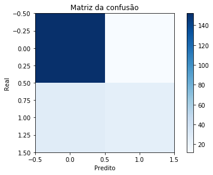

```python
from sklearn.naive_bayes import MultinomialNB

modeloMultinomial = MultinomialNB()
resultadoMultinomial = fit_and_predict_confus("MultinomialNB",modeloMultinomial,treino_d,treino_m,teste_d,teste_m)
```

### h)

#### analisando quem depositou com a variável class_saldo

```python
classes_saldo = len(df.class_saldo.unique())
lista_resultados=[]
for i in range(classes_saldo):
    tamanho_classe_saldo = len(df[df.class_saldo==i])
    depositaram_saldo = len(df[(df.class_saldo==i) & (df.y==1)])
    perc = (depositaram_saldo/tamanho_classe_saldo)*100
    lista_resultados.append(perc)
    print("percentual dos clientes na classe saldo"+str(i)+" que fizeram o depósito %.2f%%" %perc)
```

```
percentual dos clientes na classe saldo0 que fizeram o depósito 16.39%
percentual dos clientes na classe saldo1 que fizeram o depósito 18.79%
percentual dos clientes na classe saldo2 que fizeram o depósito 19.85%
percentual dos clientes na classe saldo3 que fizeram o depósito 23.91%
percentual dos clientes na classe saldo4 que fizeram o depósito 25.26%
percentual dos clientes na classe saldo5 que fizeram o depósito 27.18%
percentual dos clientes na classe saldo6 que fizeram o depósito 37.31%
percentual dos clientes na classe saldo7 que fizeram o depósito 32.84%
percentual dos clientes na classe saldo8 que fizeram o depósito 30.19%
percentual dos clientes na classe saldo9 que fizeram o depósito 30.61%
percentual dos clientes na classe saldo10 que fizeram o depósito 25.98%
```

```python
from bokeh.plotting import figure, show

from bokeh.io import output_notebook
output_notebook()
```

```python
y=lista_resultados
N = len(y)
x = range(N)

fig = figure(plot_width=300, plot_height=300,title='Gráfico usando bokeh')
fig.line(x, y, line_width=4)
fig.circle(x, y, fill_color="yellow", size=10)
fig.yaxis.axis_label = "Percentual %"
fig.xaxis.axis_label = "classes de saldo"

show(fig)
```

[interactive chart not shown]

##### analisando os clientes que fizeram o depósito relacioando com a variável empréstimo

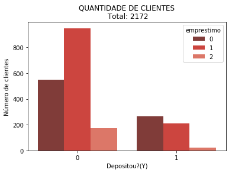

```python
clientes = sn.countplot(data=df,x='y',hue='emprestimo',palette='Reds_d')


plt.title('QUANTIDADE DE CLIENTES\n Total: %s' %(df.shape[0]))
plt.xlabel('Depositou?(Y)')
plt.ylabel('Número de clientes')
plt.show()
```

#### analisando clientes que depositaram e a variável profissão

```python
contatos = df.t_e.unique()
resultado_deposito=[]
print("CLIENTES QUE ESTUDAM OU TRABALHAM\n\n")
print("CLASSE 1 : ESTUDANTES\nCLASSE 2: TRABALHAM")
for i in contatos:

    qtd_clientes = len(df[df.t_e==i])
    depositaram = len(df[(df.t_e==i) & (df.y==1)])

    print("Quantidade de clientes da classe "+str(i)+":"+ str(qtd_clientes))

    perc = (depositaram/qtd_clientes)*100
    resultado_deposito.append(perc)
    print("percentual dos clientes na classe "+str(i)+" que fizeram o depósito %.2f%%" %perc)
```

```
CLIENTES QUE ESTUDAM OU TRABALHAM


CLASSE 1 : ESTUDANTES
CLASSE 2: TRABALHAM
Quantidade de clientes da classe 2:2132
percentual dos clientes na classe 2 que fizeram o depósito 22.47%
Quantidade de clientes da classe 1:40
percentual dos clientes na classe 1 que fizeram o depósito 47.50%
```

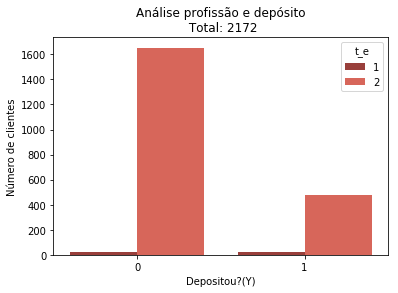

```python
clientes = sn.countplot(data=df,x='y',hue='t_e',palette='Reds_d')


plt.title('Análise profissão e depósito\n Total: %s' %(df.shape[0]))
plt.xlabel('Depositou?(Y)')
plt.ylabel('Número de clientes')
plt.show()
```

#### analisando clientes que depositaram e a variável educação

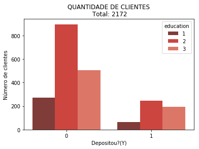

```python
clientes = sn.countplot(data=df,x='y',hue='education',palette='Reds_d')


plt.title('QUANTIDADE DE CLIENTES\n Total: %s' %(df.shape[0]))
plt.xlabel('Depositou?(Y)')
plt.ylabel('Número de clientes')
plt.show()
```

#### analisando clientes que depositaram e a variável tempo de ligação

```python
lista = sorted(df.clas_temp_lig.unique())
resultados=[]
for i in lista:
    tamanho = len(df[df.clas_temp_lig==i])
    depositaram = len(df[(df.clas_temp_lig==i) & (df.y==1)])
    perc = (depositaram/tamanho)*100
    resultados.append(perc)
    print("percentual dos clientes da classe tempo de ligação "+str(i)+"\n que fizeram o depósito %.2f%%" %perc)
```

```
percentual dos clientes da classe tempo de ligação 0
 que fizeram o depósito 0.50%
percentual dos clientes da classe tempo de ligação 1
 que fizeram o depósito 5.13%
percentual dos clientes da classe tempo de ligação 2
 que fizeram o depósito 8.77%
percentual dos clientes da classe tempo de ligação 3
 que fizeram o depósito 17.07%
percentual dos clientes da classe tempo de ligação 4
 que fizeram o depósito 24.76%
percentual dos clientes da classe tempo de ligação 5
 que fizeram o depósito 31.21%
percentual dos clientes da classe tempo de ligação 6
 que fizeram o depósito 33.94%
percentual dos clientes da classe tempo de ligação 7
 que fizeram o depósito 38.36%
percentual dos clientes da classe tempo de ligação 8
 que fizeram o depósito 47.37%
percentual dos clientes da classe tempo de ligação 9
 que fizeram o depósito 42.11%
percentual dos clientes da classe tempo de ligação 10
 que fizeram o depósito 46.15%
percentual dos clientes da classe tempo de ligação 11
 que fizeram o depósito 60.98%
percentual dos clientes da classe tempo de ligação 12
 que fizeram o depósito 52.63%
percentual dos clientes da classe tempo de ligação 13
 que fizeram o depósito 72.41%
percentual dos clientes da classe tempo de ligação 14
 que fizeram o depósito 84.21%
percentual dos clientes da classe tempo de ligação 15
 que fizeram o depósito 61.11%
percentual dos clientes da classe tempo de ligação 16
 que fizeram o depósito 88.24%
percentual dos clientes da classe tempo de ligação 17
 que fizeram o depósito 75.00%
percentual dos clientes da classe tempo de ligação 18
 que fizeram o depósito 75.00%
percentual dos clientes da classe tempo de ligação 19
 que fizeram o depósito 71.43%
```

[output cut: 21 more lines]

```
 que fizeram o depósito 0.00%
percentual dos clientes da classe tempo de ligação 31
 que fizeram o depósito 100.00%
percentual dos clientes da classe tempo de ligação 32
 que fizeram o depósito 100.00%
percentual dos clientes da classe tempo de ligação 33
 que fizeram o depósito 100.00%
percentual dos clientes da classe tempo de ligação 34
 que fizeram o depósito 100.00%
percentual dos clientes da classe tempo de ligação 40
 que fizeram o depósito 100.00%
percentual dos clientes da classe tempo de ligação 46
 que fizeram o depósito 100.00%
percentual dos clientes da classe tempo de ligação 50
 que fizeram o depósito 0.00%
```

```python
y=resultados
N = len(y)
x = range(N)
vbar = figure(plot_width=300, plot_height=300)
vbar.vbar(x=x, width=0.5, top=y, color="firebrick")

vbar.xaxis.axis_label = "classe de ligações"
vbar.yaxis.axis_label = "percentual"

show(vbar)
```

[interactive chart not shown]

```python
df.columns
```

```
Index(['education', 'campaign', 'y', 't_e', 'class_saldo', 'emprestimo',
       'clas_temp_lig', 'cont_antes'],
      dtype='object')
```

#### analisando clientes que depositaram e a variável cont_antes

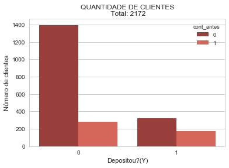

```python
clientes = sn.countplot(data=df,x='y',hue='cont_antes',palette='Reds_d')

plt.title('QUANTIDADE DE CLIENTES\n Total: %s' %(df.shape[0]))
plt.xlabel('Depositou?(Y)')
plt.ylabel('Número de clientes')
plt.show()
```

## 3ª questão

```python
df.columns
```

```
Index(['education', 'campaign', 'y', 't_e', 'class_saldo', 'emprestimo',
       'clas_temp_lig', 'cont_antes'],
      dtype='object')
```

```python
train_columns = ['education','class_saldo','emprestimo','clas_temp_lig','cont_antes']
```

```python
porcentagem_treino = 0.8
porcentagem_teste = 0.1
X = df[train_columns].values
Y = df['y'].values

tamanho_de_treino = int(porcentagem_treino*len(Y))
tamanho_de_teste = int(porcentagem_teste*len(Y))
tamanho_de_validacao = len(Y)-tamanho_de_treino-tamanho_de_teste

treino_dados = X[:tamanho_de_treino]
treino_marcacoes = Y[:tamanho_de_treino]

fim_de_treino = tamanho_de_treino+tamanho_de_teste

teste_dados = X[tamanho_de_treino:fim_de_treino]
teste_marcacoes = Y[tamanho_de_treino:fim_de_treino]

validacao_dados = X[fim_de_treino:]
validacao_marcacoes = Y[fim_de_treino:]
```

```python
from sklearn.metrics import confusion_matrix

def fit_and_predict(nome,modelo,treino_dados,treino_marcacoes,test_dados,test_marcacoes):
    modelo.fit(treino_dados,treino_marcacoes)
    resultado = modelo.predict(test_dados)
    acertos = 0
    tamanho = len(test_marcacoes)
    for i in range(tamanho):
        if test_marcacoes[i]==resultado[i]:
            acertos = acertos+1
    perc = acertos*100/tamanho
    print('Acerto %s: %.2f%%'%(nome,perc))


    return perc
```

```python
from sklearn.naive_bayes import MultinomialNB
modeloMultinomial = MultinomialNB()
resultadoMultinomial = fit_and_predict("MultinomialNB",modeloMultinomial,treino_dados,treino_marcacoes,teste_dados,teste_marcacoes)
```

```
Acerto MultinomialNB: 79.72%
```

```python
from sklearn.ensemble import AdaBoostClassifier
modeloAdaBoost = AdaBoostClassifier()
resultadoAdaBoost = fit_and_predict("AdaBoostClassifier",modeloAdaBoost,treino_dados,treino_marcacoes,teste_dados,teste_marcacoes)
```

```
Acerto AdaBoostClassifier: 83.87%
```

```python
from sklearn.multiclass import OneVsRestClassifier
from sklearn.svm import LinearSVC
modeloOneVsRest = OneVsRestClassifier(LinearSVC(random_state=0))
resultadoOneVsRest = fit_and_predict("OneVsRest",modeloOneVsRest,treino_dados,treino_marcacoes,teste_dados,teste_marcacoes)
```

```
Acerto OneVsRest: 81.57%
```

```python
from sklearn.multiclass import OneVsOneClassifier
modeloOneVsOne = OneVsOneClassifier(LinearSVC(random_state=0))
resultadoOneVsOne = fit_and_predict("OneVsOne",modeloOneVsOne,treino_dados,treino_marcacoes,teste_dados,teste_marcacoes)
```

```
Acerto OneVsOne: 81.57%
```

```python
from sklearn.ensemble import RandomForestClassifier
modelRandomForestClassifier= RandomForestClassifier()
resultadoRandomForestClassifier = fit_and_predict("RandomForestClassifier",modelRandomForestClassifier,treino_dados,treino_marcacoes,teste_dados,teste_marcacoes)
```

```
Acerto RandomForestClassifier: 77.88%
```

```python
from sklearn.ensemble import GradientBoostingClassifier

modelGradientBoostingClassifier= GradientBoostingClassifier(n_estimators=100, learning_rate=1.0, max_depth=1, random_state=0)

resultadoGradientBoostingClassifier=fit_and_predict("GradientBoostingClassifier",modelGradientBoostingClassifier,treino_dados,treino_marcacoes,teste_dados,teste_marcacoes)
```

```
Acerto GradientBoostingClassifier: 83.87%
```

```python
from sklearn.model_selection import cross_val_score
import numpy as np
```

```python
def folding(modelo,k):
    print("Executando com qtd de divisões:  with k=%d" % k)
    scores = cross_val_score(modelo, teste_dados, teste_marcacoes, cv=k)


    return "%s: %.2f%%" % (modelo.__class__.__name__, (np.mean(scores)*100)),(np.mean(scores)*100)
```

```python
text_sai,foldingMultinomial = folding(MultinomialNB(),6)
print(text_sai)
```

```
Executando com qtd de divisões:  with k=6
MultinomialNB: 79.21%
```

```python
text_sai,foldingAdaBoost=folding(AdaBoostClassifier(),6)
print(text_sai)
```

```
Executando com qtd de divisões:  with k=6
AdaBoostClassifier: 80.11%
```

```python
text_sai,foldingOneVsOne = folding(OneVsOneClassifier(LinearSVC(random_state=0)),6)
print(text_sai)
```

```
Executando com qtd de divisões:  with k=6
OneVsOneClassifier: 82.90%
```

```python
text_sai,foldingOneVsRest = folding(OneVsRestClassifier(LinearSVC(random_state=0)),6)
print(text_sai)
```

```
Executando com qtd de divisões:  with k=6
OneVsRestClassifier: 82.90%
```

```python
text_sai,foldingGradient = folding(GradientBoostingClassifier(n_estimators=100, learning_rate=1.0, max_depth=1, random_state=0),6)
print(text_sai)
```

```
Executando com qtd de divisões:  with k=6
GradientBoostingClassifier: 78.75%
```

```python
text_sai,foldingRandomForest = folding(RandomForestClassifier(),6)
print(text_sai)
```

```
Executando com qtd de divisões:  with k=6
RandomForestClassifier: 76.96%
```

### f)

#### linear_model.LinearRegression() não se aplica, pois é utilizada para estimar valores reais (custo de residências, número de chamadas, vendas totais, etc) baseado em variáveis contínuas. É uma relação entre variáveis dependentes e independentes ajustando a melhor linha.

#### KMeans também não seria muito recomendado, sua acurácea ficou muito inferior em relação as outras acima que tiveram valores próximos. KMeans é muito usado em aprendizagem não supervisionada talvez por essa finalidade não tenha tido um bom resultado. O resultado no entando melhora quando diminuímos a quantidade de agrupamento ou clusters

```python
from sklearn import linear_model
modelLinearRegression = linear_model.LinearRegression()
resultadoLinearRegression=fit_and_predict("modelLinearRegression",modelLinearRegression,treino_dados,treino_marcacoes,teste_dados,teste_marcacoes)
```

```
Acerto modelLinearRegression: 0.00%
```

```python
from sklearn.cluster import KMeans
modelk_means = KMeans(n_clusters=8, random_state=0)
resultadok_means=fit_and_predict("modelk_means",modelk_means,treino_dados,treino_marcacoes,teste_dados,teste_marcacoes)
```

```
Acerto modelk_means: 7.83%
```

## 4ª questão

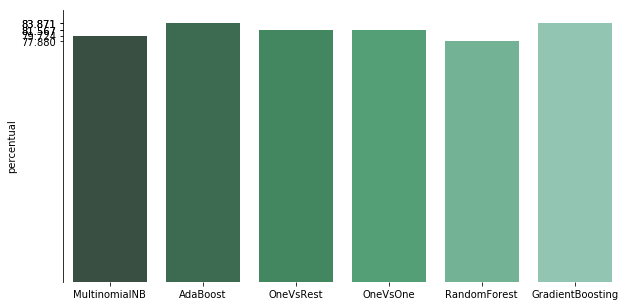

```python
eixo_x=["MultinomialNB","AdaBoost","OneVsRest","OneVsOne","RandomForest","GradientBoosting"]
valores_resultados=[resultadoMultinomial,resultadoAdaBoost,resultadoOneVsRest,resultadoOneVsOne,resultadoRandomForestClassifier,resultadoGradientBoostingClassifier]

f, (ax1) = plt.subplots(1, 1, figsize=(10, 5), sharex=True)
x = np.array(eixo_x)
y1 =valores_resultados
sn.barplot(x, y1, palette="BuGn_d", ax=ax1)
ax1.set_ylabel("percentual")

sn.despine(bottom=True)

plt.setp(f.axes, yticks=y1)

plt.show()
```

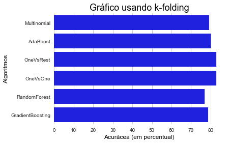

```python
alg = {"Multinomial": foldingMultinomial, "AdaBoost": foldingAdaBoost, "OneVsRest":foldingOneVsRest, "OneVsOne": foldingOneVsOne, "RandomForest": foldingRandomForest,"GradientBoosting":foldingGradient}

algoritmos = [i for i in alg.keys()]

resultados = [j for j in alg.values()]

azul = "blue"

preto = "black"
sn.set(style="whitegrid")

g = sn.barplot(x=resultados, y=algoritmos, color=azul)
g.axes.set_title('Gráfico usando k-folding', fontsize=18,color="black",alpha=2)

g.set_xlabel("Acurácea (em percentual)", size = 12,color="black")
g.set_ylabel("Algoritmos", size = 12,color="black")
sn.despine(left=True, bottom=True)

plt.show()
```